# Week 1 Exercise Part B

Author

Peter Lund Andersen

### Setup

Normally this would have the tag `#| result = FALSE` But for demonstration purposes have we left the options clean for this Quatro.

```r
library(tidyverse) #used primarily for ggplot2
library(scales) #used for nicer log-scales with 'log_breaks()'
```

### Simulation

```r
set.seed(426) #set.seed for reproducibility
n <- 100
sim <- rlnorm(n, meanlog = 5, sdlog = 0.5)
tbl <- tibble(sim)
```

### Histogram of the simulated data

We now use ggplot to take the simulated data, and using the plotting `geom_histogram` we can make a histogram of the simulated data.

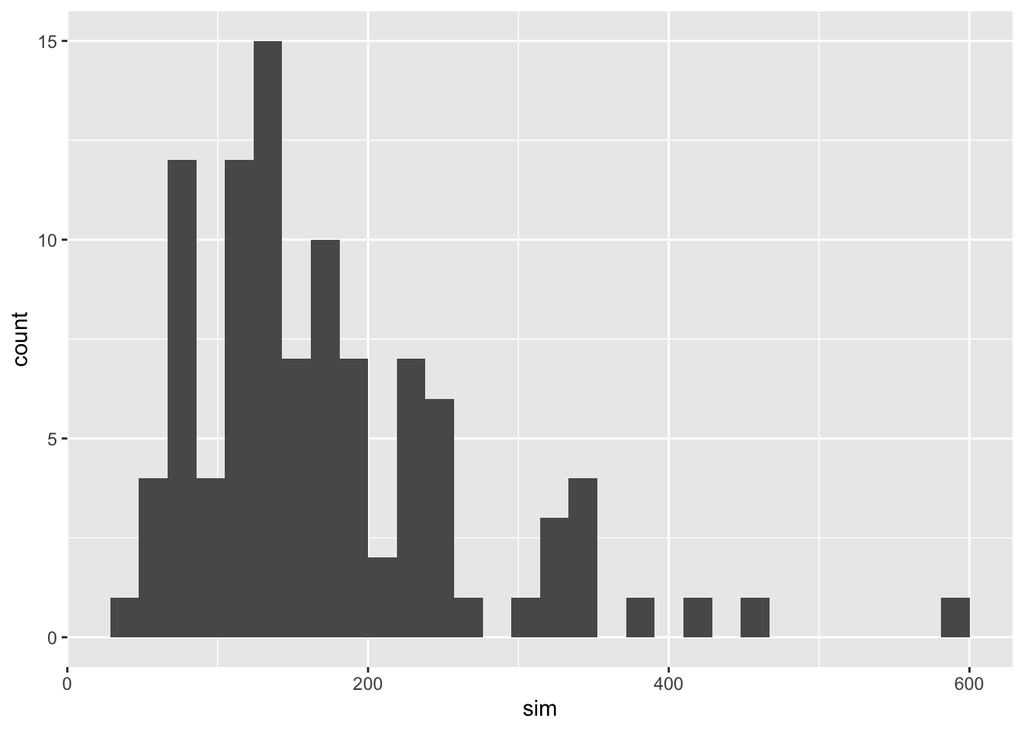

```r
ggplot(mapping = aes(x = sim), data = tbl) +
  geom_histogram()
```

We here get the message that ‘stat_bin()` using `bins = 30`. Pick better value with `binwidth’. We can also apply [Freedman–Diaconis rule](https://en.wikipedia.org/wiki/Freedman–Diaconis_rule), which let the number of bins be given as

$$\text{binwidth} = 2 \cdot \frac{\text{IQR}(x)}{n^{1/3}},$$

where $IQR(x)$ is the Interquartile range of the samples $x$ and $n$ is the number of samples. Then we get the following histogram.

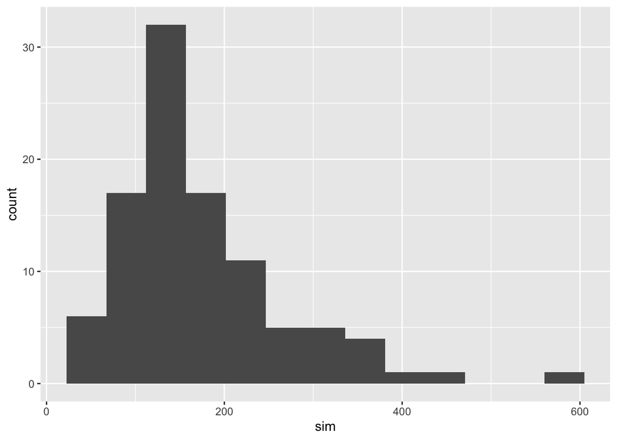

```r
freedman_diaconis <- function(x){
  return(2 * IQR(x) / length(x)^(1/3))
}

ggplot(mapping = aes(x = sim), data = tbl) +
  geom_histogram(binwidth = function(x) freedman_diaconis(x))
```

This still isnt all that pretty, but it is better. And this mostly seems to have somthing to do with the numbers of samples.

### Histogram of the log-transformed simulated data

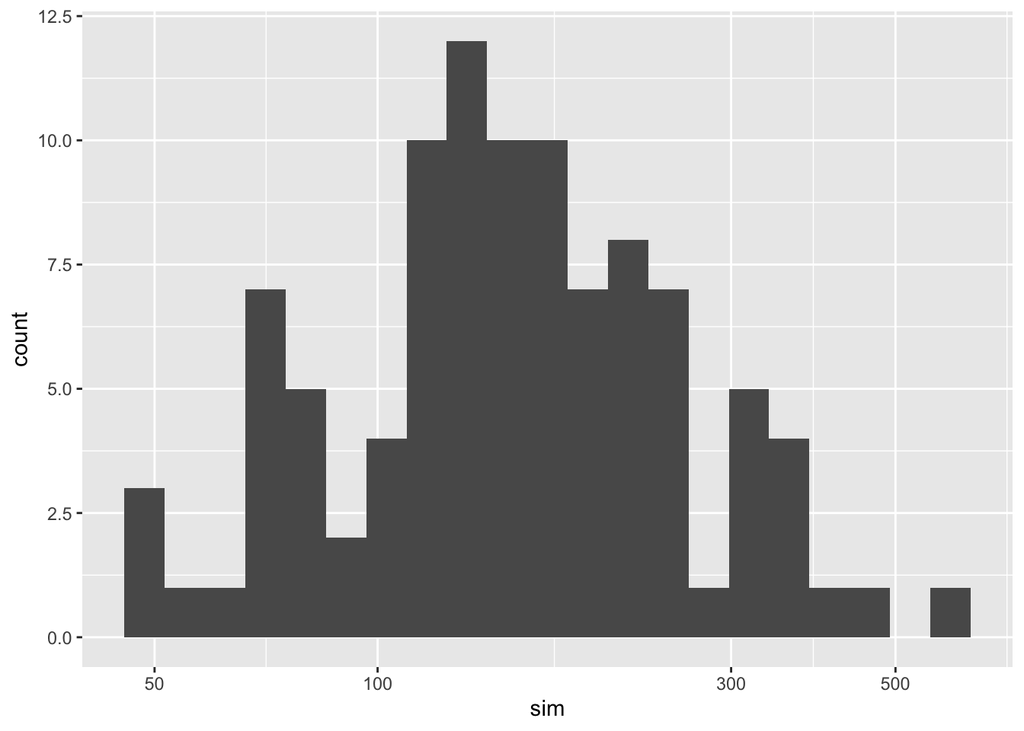

```r
ggplot(mapping = aes(x = sim), data = tbl) +
  geom_histogram(binwidth = function(x) freedman_diaconis(log(x))) +
  scale_x_log10(breaks = log_breaks())
```

We here add the scaling with `scale_x_log10` to transform our x-axis to a log-scale. It follows from the definition of log-normal distributions this should look like a normal distribution, but it looks like we need more samples for it to have show a precise bell-curve.

### Violin plot

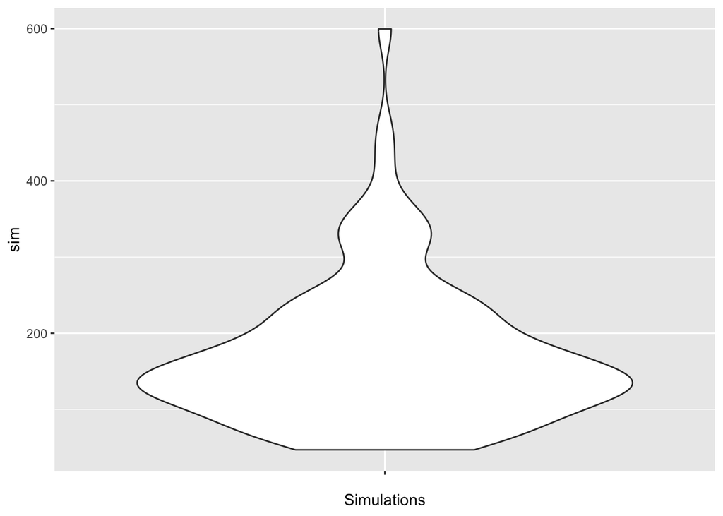

```r
ggplot(mapping = aes(x = " ", y = sim)) +
  geom_violin() +
  xlab("Simulations")
```

Instead of plotting using `geom_histogram` we can instead use `geom_violin` to transform the data into a violin-plot. We here see that our samples seems to have some bumps for higher values, this indicates that we sampled some values from the heavy tail of the distribution. For our samples we have a mean of the sampled values is equal to 172.7 and the standard deviation of the values 96.6. This should be compared to the theoretical values of 168.2 and a standard deviation of 89.6. [Formulas for mean and variance of log-normal](https://en.wikipedia.org/wiki/Log-normal_distribution).